# Reflection on Labelled Data in R

Module 06 | Advanced Data Wrangling

Brian Vuong

MSDM | Cal Poly Pomona

October 25, 2026

# Introduction

## Module 06: Reflection Overview

This presentation reflects on the concepts and techniques introduced in Module 06, particularly labelled data, exploratory data analysis, hypothesis testing, and data cleaning in R.

I will also discuss how these lessons relate to my individual analytical objective within our MSDM Culminating Experience Project (CEP).

1. Understanding labelled data
2. Connecting analytical techniques to my CEP
3. Reflecting on initial data cleaning
4. Understanding further data cleaning
5. Comparing the two cleaning approaches
6. Applying the lessons to my analytical objective

## My CEP and Individual Responsibility

### Wellness Ranch Equine Assisted Therapy

Our MSDM CEP is a group project focused on strengthening the digital marketing capabilities of Wellness Ranch Equine Assisted Therapy, a nonprofit organization.

The broader project includes website improvements, search engine optimization, analytics, Google Ad Grants, and digital marketing strategy.

My individual responsibility is:

**AO3: Prepare, Launch, and Optimize Google Ad Grants Campaigns**

My objective involves:

- Evaluating Google Ad Grants eligibility and readiness
- Supporting the application process
- Preparing campaign structure and keywords
- Helping launch compliant Google Search campaigns
- Monitoring campaign readiness and compliance
- Using available performance information to guide campaign management and optimization

Other group members are responsible for different analytical objectives, including data preparation and specialized campaign performance analysis.

# Step 1: Labelled Data and Analysis

## Prompt 1A: Understanding Labelled Data

**Assignment Prompt:**

In Step 1, you learned how to read SPSS data into RStudio and conduct EDA and hypothesis testing.

What is labelled data? Does your MSDM CEP involve labelled data? Explain why or why not.

### My Reflection

Labelled data refers to data containing descriptive information about variables or their possible values.

In SPSS, variable labels describe what a variable represents, while value labels explain the meaning of coded responses.

For example, a survey might record satisfaction using numbers from 1 to 5.

Without labels, these numbers may be difficult to interpret correctly.

With labels, researchers can understand the meaning of each response and select appropriate analytical methods.

## Example of Labelled Data

| Numerical Code | Value Label |
| --- | --- |
| 1 | Very dissatisfied |
| 2 | Dissatisfied |
| 3 | Neutral |
| 4 | Satisfied |
| 5 | Very satisfied |

Although the responses are stored as numbers, they represent ordered categories.

This distinction matters because numeric codes should not automatically be treated as continuous measurements.

### What I Learned

I learned that understanding how data is coded is an important step before conducting exploratory analysis or hypothesis testing.

Misinterpreting variable labels could lead to incorrect conclusions.

## Does My CEP Involve Labelled Data?

My individual CEP objective does not primarily involve SPSS-labelled survey data.

Instead, AO3 focuses on Google Ad Grants eligibility, campaign preparation, and advertising performance information.

However, categorical labels can still be useful for organizing my work.

For example, I may classify organizational readiness using categories such as:

- **Ready:** The requirement has been satisfied.
- **Partially Ready:** Some requirements remain incomplete.
- **Not Ready:** Significant improvements are required.
- **Unable to Verify:** Additional information is needed.

These classifications are not necessarily SPSS-labelled variables, but they serve a similar interpretive purpose by making categorical information easier to understand.

## Why Labelled Data Matters to AO3

Understanding labelled data can help me organize and interpret information used during Google Ad Grants preparation.

### Readiness Assessment

Categorical information can describe:

- Eligibility status
- Website readiness
- Conversion tracking readiness
- Campaign approval status
- Compliance requirements

### Campaign Information

Categorical variables can identify:

- Campaign names
- Ad groups
- Keyword categories
- Search intent
- Campaign status

**My takeaway:** Even though my AO3 does not primarily use SPSS data, the principle of correctly defining and interpreting categories remains relevant to my work.

## Reading SPSS Data into R

Step 1 also introduced how to import SPSS data into RStudio.

The `haven` package allows researchers to read SPSS files while preserving important variable metadata.

```r
library(haven)
library(dplyr)

# Import an SPSS dataset
data <- read_sav("survey_data.sav")

# Inspect data structure
glimpse(data)

# Review variable labels
attr(data$satisfaction, "label")

# Convert labelled values to factors
data <- data |>
  mutate(
    satisfaction_factor =
      as_factor(satisfaction)
  )
```

This example demonstrates how R can preserve and interpret labelled information during analysis.

The code is illustrative rather than a procedure performed for my CEP.

## Prompt 1B: Relevant Analytical Techniques

**Assignment Prompt:**

What techniques are relevant for your MSDM CEP?

Please elaborate on how these approaches might help you address your analytical objective for the CEP.

Several techniques from Step 1 are relevant to my AO3.

1. **Exploratory Data Analysis (EDA):** Understand patterns and unusual observations.
2. **Descriptive Statistics:** Summarize campaign performance and readiness.
3. **Categorical Analysis:** Organize eligibility and readiness assessments.
4. **Data Visualization:** Communicate campaign trends and results.
5. **Hypothesis Testing:** Evaluate performance differences when sufficient data are available.

## Applying EDA to My AO3

Exploratory Data Analysis helps researchers understand a dataset before drawing conclusions.

For AO3, EDA may become useful after Google Ad Grants campaigns are launched and performance data are available.

I could examine:

- Advertising impressions over time
- Clicks across campaigns
- Click-through rates
- Keyword and search-term patterns
- Conversion activity
- Changes in campaign performance

EDA would help identify patterns that deserve further investigation.

However, my immediate responsibility is primarily focused on eligibility, readiness, application, campaign development, and launch.

Detailed click-through and conversion performance analysis is also supported by another member’s analytical objective.

## Descriptive Statistics and Campaign Metrics

If campaign data become available, descriptive statistics can help summarize advertising performance.

| Metric | Purpose |
| --- | --- |
| Impressions | Measures how often advertisements appear |
| Clicks | Measures user interactions with advertisements |
| CTR | Evaluates clicks relative to impressions |
| Conversions | Tracks defined meaningful actions |
| Conversion Rate | Measures conversions relative to interactions |

These measures can support campaign monitoring and optimization.

The conversion-rate formula assumes a click-based denominator; platform reporting definitions may differ.

## Hypothesis Testing and AO3

Hypothesis testing could be useful if sufficient campaign data become available later in the project.

For example, a research question might ask whether two advertisement approaches produce different conversion rates.

However, statistical testing requires:

- Appropriate data
- Clearly defined hypotheses
- Sufficient observations
- Suitable statistical assumptions
- Careful interpretation

For my AO3, hypothesis testing is a possible future application rather than the primary method.

**My takeaway:** The analytical technique should match the research objective, the available data, and the decision that needs to be made.

# Step 2: Initial Data Cleaning

## Prompt 2: Initial Data Cleaning

**Assignment Prompt:**

In Step 2, you saw the initial data cleaning process.

Describe it and what lessons you got from it.

### My Reflection

The initial data cleaning process introduced the importance of examining data quality before performing analysis.

The general purpose of initial cleaning is to identify problems that could interfere with accurate interpretation.

These may include:

- Missing observations
- Duplicate records
- Incorrect variable types
- Inconsistent coding
- Unexpected values
- Unclear variable definitions

The exact procedures used in the Step 2 classroom demonstration should be documented separately.

## Understanding Initial Data Cleaning in R

The following example illustrates common initial data inspection techniques.

```r
library(haven)
library(dplyr)

# Import example data
data <- read_sav("survey_data.sav")

# Inspect dimensions
dim(data)

# Review variable structure
glimpse(data)

# Count missing values
colSums(is.na(data))

# Identify exact duplicate rows
sum(duplicated(data))

# Review summary statistics
summary(data)
```

These commands can help researchers identify potential problems before deciding how to clean the dataset.

However, identifying a potential problem does not automatically justify removing an observation.

## Lessons Learned from Initial Cleaning

The first important lesson is that raw data should be examined carefully before conducting statistical analysis.

A dataset may contain values that appear valid but are incorrectly coded or interpreted.

The second lesson is that data cleaning should be systematic.

Using reproducible R code makes it easier to document what was checked and how decisions were made.

The third lesson is that researchers should avoid removing observations without justification.

For example, missing information does not always mean that an entire record must be deleted.

**My key takeaway:** Initial data cleaning helps establish a reliable foundation for analysis, but cleaning decisions must be supported by clear reasoning.

## Connecting Step 2 to My CEP Role

My MSDM CEP is a group project with responsibilities divided among team members.

Another team member is responsible for data cleaning and preparation.

My individual objective focuses on Google Ad Grants campaign readiness, application, development, and launch.

Although I am not responsible for the group’s primary data-cleaning work, understanding initial cleaning remains useful.

It helps me recognize why accurate and consistent information matters when interpreting campaign reports.

It also allows me to communicate more effectively with teammates who prepare or validate data.

# Step 3: Further Data Cleaning

## Prompt 3: Next Phase of Data Cleaning

**Assignment Prompt:**

In Step 3, you saw the next phase of data cleaning.

Describe it and what the key takeaways are.

### My Reflection

The next phase of data cleaning builds on the initial inspection by evaluating observations more closely.

Depending on the research design, this may involve examining:

- Incomplete responses
- Inconsistent answers
- Unusual response patterns
- Implausible values
- Eligibility for inclusion
- The effect of exclusions on the dataset

These examples illustrate possible further-cleaning procedures.

The specific methods from our Step 3 classroom exercise should be identified from the module materials.

## Understanding Response Quality

One concept I learned is that response quality cannot be judged only by whether a record is complete.

A complete survey response may still contain inconsistencies.

Likewise, a partially completed response may contain useful information for certain analyses.

### Completeness

Questions to consider:

- How much information is missing?
- Which variables are affected?
- Can the observation still be used?
- Would exclusion affect the sample?

### Consistency

Questions to consider:

- Are responses logically consistent?
- Are there implausible values?
- Are response patterns unusual?
- Is there sufficient evidence to justify exclusion?

**Key insight:** Data quality requires more than applying automatic filtering rules.

## Key Takeaways from Step 3

1. **Cleaning requires judgment.** Unusual observations are not necessarily invalid.
2. **Exclusion criteria matter.** Researchers should explain why records are removed.
3. **Sample size matters.** Removing too many observations can reduce statistical power.
4. **Bias is possible.** Excluding certain respondents may change the characteristics of the final sample.
5. **Documentation is essential.** Cleaning decisions should be transparent and reproducible.

## How Step 3 Relates to My AO3

Although another group member handles data cleaning, I still need to understand how data quality affects analysis.

For example, when reviewing Google Ads performance information, I should be aware of:

- Incomplete reporting periods
- Incorrect metric definitions
- Duplicate data exports
- Inconsistent campaign categories
- Potential conversion tracking errors

Understanding these issues can help me avoid interpreting inaccurate performance summaries.

My responsibility is not to take over the data-cleaning role, but to use reliable information when making decisions related to Google Ad Grants.

# Step 4: Comparing the Approaches

## Prompt 4: Differences and Impact

**Assignment Prompt:**

What are the big differences between the two approaches and the impact on the final sample size and response quality?

### My Reflection

The main conceptual difference between initial cleaning and further cleaning is the depth of evaluation.

Initial cleaning generally focuses on identifying structural problems and inconsistencies.

Further cleaning may apply more specific criteria to determine whether observations are suitable for analysis.

Both stages contribute to data reliability.

However, they can have different effects on the final analytical sample.

## Comparing Step 2 and Step 3

| Dimension | Initial Cleaning | Further Cleaning |
| --- | --- | --- |
| Primary focus | Data structure | Analytical suitability |
| Typical checks | Types, missingness, duplicates | Completeness, consistency, eligibility |
| Main goal | Identify obvious problems | Evaluate observations more closely |
| Sample size | May remain similar or decrease | May decrease further |
| Main benefit | Improved consistency | More defensible inclusion criteria |
| Main concern | Overlooking subtle problems | Excluding valid observations |

This comparison summarizes the general distinction.

The exact differences should be confirmed against the procedures demonstrated in the module.

## Impact on Final Sample Size

Data cleaning can affect how many observations remain available for analysis.

A useful way to evaluate the impact is to compare sample sizes before and after each cleaning stage.

[output not shown]

Without the actual classroom results, I cannot determine which approach removed more observations.

The important lesson is to report the sample-size changes rather than assuming that more aggressive cleaning is always better.

## Impact on Response Quality

### Potential Benefits

Cleaning can:

- Correct coding errors
- Reduce duplicate records
- Identify invalid observations
- Improve consistency
- Strengthen analytical reliability

### Potential Trade-offs

Cleaning may also:

- Reduce sample size
- Lower statistical power
- Exclude useful information
- Introduce selection bias
- Affect representativeness

**My takeaway:** The goal is not simply to maximize or minimize sample size.

The goal is to retain appropriate observations while addressing genuine data-quality problems.

## What This Comparison Taught Me

Before this module, I primarily thought of data cleaning as removing incorrect or incomplete information.

I now understand that cleaning decisions can change the composition of a dataset and influence the conclusions researchers draw.

A smaller sample is not automatically more accurate.

Similarly, a larger sample is not automatically better if it contains invalid records.

The most important consideration is whether the cleaning criteria are appropriate, transparent, and consistent with the research objective.

# Applying the Lessons to AO3

## Collaboration Within Our CEP Group

Our CEP requires collaboration because the analytical objectives are interconnected.

### My AO3 Responsibilities

- Google Ad Grants readiness
- Eligibility verification
- Application support
- Keyword and campaign planning
- Campaign launch
- Compliance monitoring
- Campaign management recommendations

### Related Team Contributions

Other group members support:

- Website and SEO improvements
- GA4 measurement and tracking
- Data preparation and quality
- Detailed advertising performance analysis
- Broader strategic recommendations

Understanding the data-cleaning process helps me collaborate with these team members.

It also helps ensure that campaign recommendations are based on reliable information.

## A Practical Example for AO3

Suppose a campaign report shows an unexpected increase in conversions.

Before interpreting the result as an improvement, I should consider whether:

1. Conversion tracking was configured consistently.
2. The reporting periods are comparable.
3. Duplicate conversion events were recorded.
4. The conversion definition changed during the period.
5. The results reflect meaningful organizational actions.

These questions demonstrate how data-quality awareness supports responsible campaign interpretation.

They do not mean that I personally perform all data-cleaning tasks.

## My Learning-to-Application Workflow

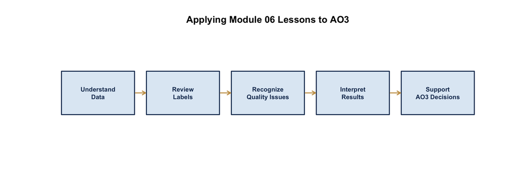

The module helped me understand the connection between data preparation, analytical interpretation, and decision-making.

# Final Reflection

## My Biggest Lessons from Module 06

**First**, I learned that labelled data provides context that helps researchers interpret coded variables.

**Second**, I learned that exploratory analysis should come before formal statistical conclusions.

**Third**, I learned that data cleaning involves both technical procedures and methodological decisions.

**Fourth**, I recognized that cleaning criteria can affect sample size, response quality, and research conclusions.

**Finally**, I learned that understanding data preparation is valuable even when another team member performs the work.

## Final Reflection: My Role in the CEP

My individual analytical objective focuses on preparing, launching, and optimizing Google Ad Grants campaigns for Wellness Ranch Equine Assisted Therapy.

Although another group member is responsible for data cleaning, the concepts from this module remain relevant to my work.

I need to understand the quality and meaning of the information used to evaluate campaign readiness and advertising performance.

This knowledge will help me communicate effectively with my teammates and interpret results more carefully.

Most importantly, I learned that successful data-driven marketing decisions depend on accurate information, appropriate analytical methods, and transparent processes.

## Conclusion

**My overall takeaway:**

Module 06 showed me that understanding data is just as important as analyzing it.

Labelled data helps explain what variables mean, while data cleaning helps improve the reliability of the information used for analysis.

Even though data cleaning is not my primary CEP responsibility, understanding these concepts will help me contribute more effectively to our group’s Google Ad Grants project.

# References

## References and Learning Resources

**R and labelled data**

Wickham, H., Miller, E., & Smith, D. *haven: Import and Export SPSS, Stata and SAS Files.*

https://haven.tidyverse.org/

**Data analysis**

Wickham, H., Çetinkaya-Rundel, M., & Grolemund, G. *R for Data Science (2nd ed.).*

https://r4ds.hadley.nz/

**Missing data**

Little, R. J. A., & Rubin, D. B. (2019). *Statistical Analysis with Missing Data* (3rd ed.). Wiley.

**Quarto**

Quarto. *RevealJS Presentations.*

https://quarto.org/docs/presentations/revealjs/

**CEP project source**

MSDM Group 4. *Wellness Ranch Equine Assisted Therapy Culminating Experience Project.* Group working document.

## Thank You

### Reflection on Labelled Data in R

**Module 06 | Advanced Data Wrangling**

*Understanding data quality helps support better analytical decisions.*

**Questions and Discussion**